# Compare the Difference in Inaugurals over Different Times

Shiyu Liu

1/31/2018

```r
ff.all<-Corpus(DirSource(folder.path))
```

### Introduction:

In this report we will take a look at the difference bewtween the inaugurals in different eras. That is, we will try to find how the inaugurals change from 1789 to 2017. To be more specific, we will explore the changes first from the length of the sentences and words used in the speeches, and then we will try to find the different topics in different eras in the speech. Finally, we tried to find the similarity of inaugurals between each eras in US history.

### Sentences & words length changes over time:

Firstly, we read the inaugurals from the txt file and used some data cleaning/manipulation skills to link the speeches to the information of each presidents. Then we counted the total number of words and sentences in the speeches and hence calculated the average sentence length in each speech.

Here is a bar chart to show average sentence lengths in some representive Presidents’ inaugurals:

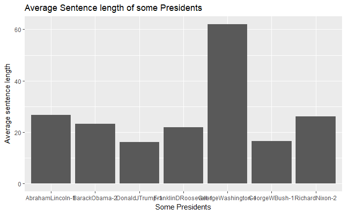

From the bar chart we can see that the first President George Washington loved to use long sentence in his speech: the average length of sentence in his speech is greater than 60 words. In contrast, President Donald Trump’s each sentence only contains about 16 words on average. This bar chart makes us to think that what happens in difference of sentence length of Trumps and George Washington is just a special case or there is a trend that presients would shorter sentences as they approach to more recent time?

To figure out this question, I linked data set of speeches to the data set with the dates of inaugurals and drew the scatter plot as following:

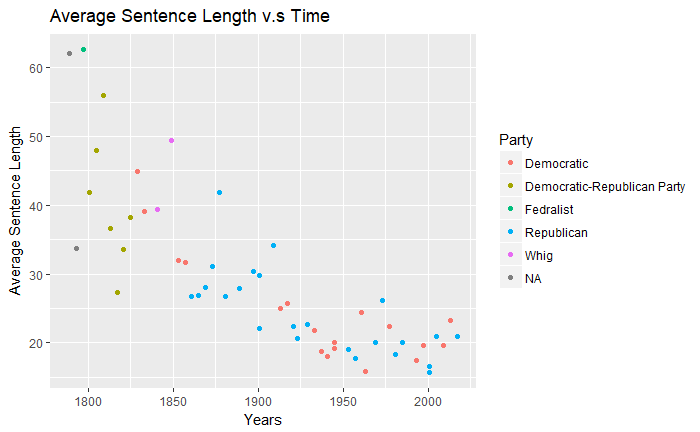

From the scatter plot we can see a trend that the average sentence length is decreasing as time passing. In this sense, more recent the inaugurals were, the shorter sentence the presidents tended to use.

We can run the linear regression using the Average Sentence Length against the Years:

```r
summary(lm(averageLength~date, data = table_1))
```

```
Call:
lm(formula = averageLength ~ date, data = table_1)

Residuals:
    Min      1Q  Median      3Q     Max
-13.451  -4.272  -1.296   3.253  19.142

Coefficients:
             Estimate Std. Error t value Pr(>|t|)
(Intercept) 286.93333   25.52410   11.24 1.57e-15 ***
date         -0.13545    0.01338  -10.12 6.87e-14 ***
---
Signif. codes:  0 ‘***’ 0.001 ‘**’ 0.01 ‘*’ 0.05 ‘.’ 0.1 ‘ ’ 1

Residual standard error: 6.732 on 52 degrees of freedom
Multiple R-squared:  0.6632,    Adjusted R-squared:  0.6568
F-statistic: 102.4 on 1 and 52 DF,  p-value: 6.874e-14
```

From the regression table we find that there are very strong significant statistical evdience saying that with variable *date* increase “averageLength” will decrease.

However, if we instead looking at the number of words in the speeches, we actually cannot see any obvious trend:

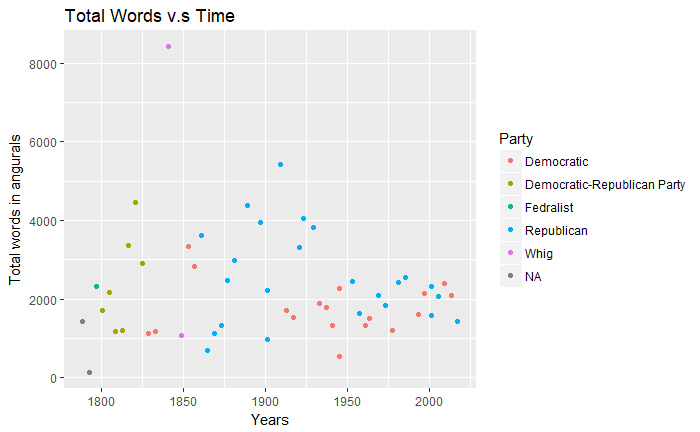

We further compared the length of words chosen in each President’s inaugural:

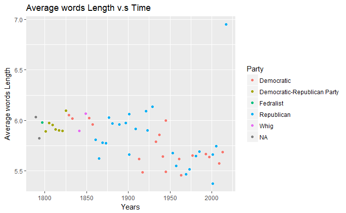

This plot shows that the presidents before 1850 liked to use longer and complicated words while more recent presidents would try to use simple words. This result also has statistical significance(very small p-value):

```r
summary(lm(nc/nwords~date, data = table_1))
```

```
Call:
lm(formula = nc/nwords ~ date, data = table_1)

Residuals:
     Min       1Q   Median       3Q      Max
-0.32582 -0.10978 -0.03461  0.09603  1.27387

Coefficients:
              Estimate Std. Error t value Pr(>|t|)
(Intercept)  8.3621402  0.9018828   9.272 1.32e-12 ***
date        -0.0013305  0.0004729  -2.813   0.0069 **
---
Signif. codes:  0 ‘***’ 0.001 ‘**’ 0.01 ‘*’ 0.05 ‘.’ 0.1 ‘ ’ 1

Residual standard error: 0.2379 on 52 degrees of freedom
Multiple R-squared:  0.1321,    Adjusted R-squared:  0.1154
F-statistic: 7.915 on 1 and 52 DF,  p-value: 0.006904
```

To conclude the first part, we found that far back in US history, the Presidents trend to use longer and more complicated words and sentences in their inaugurals while recent Presidents just did the opposite. There could be many reasons behind this, but we will not have an in-depth discussion here.

## Topic change in different era:

Seondly, we try to find what are important topics that appearing in the inaugurals via word cloud:

To show the word cloud with more meaningful words we first removed “stopword” such as “the, that, you, I”, etc. from our data set.

```r
ff.all<-tm_map(ff.all, stripWhitespace)
ff.all<-tm_map(ff.all, content_transformer(tolower))
ff.all<-tm_map(ff.all, removeWords, stopwords("english"))
ff.all<-tm_map(ff.all, removeWords, character(0))
ff.all<-tm_map(ff.all, removePunctuation)
tdm.all<-TermDocumentMatrix(ff.all)
tdm.tidy=tidy(tdm.all)
tdm.overall=summarise(group_by(tdm.tidy, term), sum(count))
```

The overall Word Cloud:

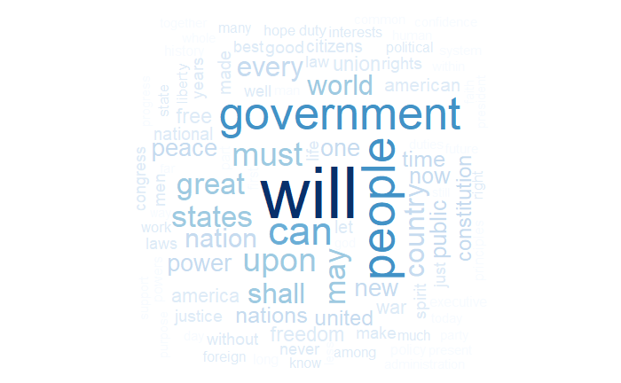

One probelm of this word cloud is that there are still some modal verb such as “will”, “must”, “shall”, “can” and some common words such as “people”, “government”, “one”. Thus, we further removed these words from the data.

We used the standard Timeline on Wikipedia to divide the history of U.S into 5 parts:

Then we drew the word cloud for each of five eras:

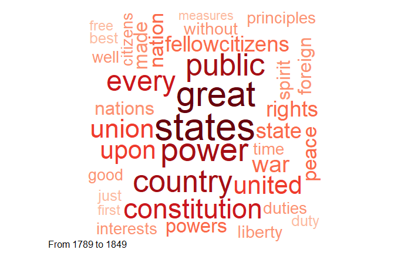

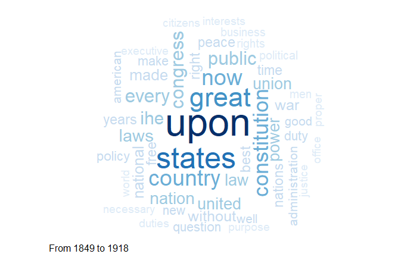

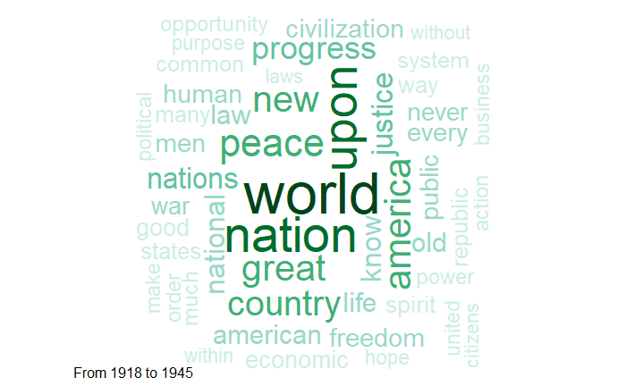

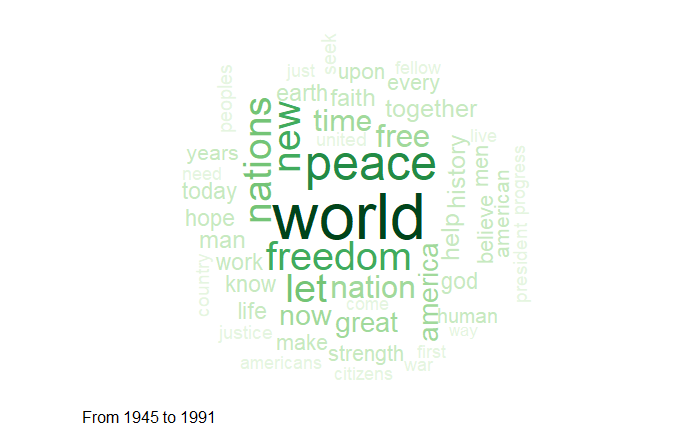

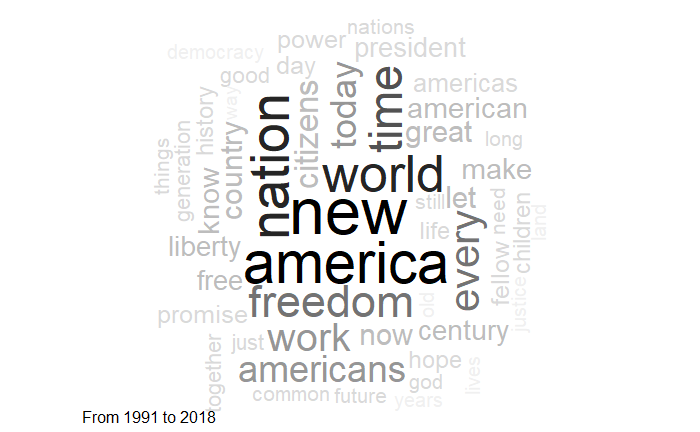

As we can see from the five word clouds, even though there are some common words in all eras, difference in the topics or words chosen are still obvious.

For example, in the graph of first two eras we can see that words such as “States” and “Constitution” are very large while in last two we find the recent leaders tried to emphasize on the importance of “World” and “Nation”. Related to U.S history, we can try to understand the change in the ideology of this changing of using words.

Also, the word “Peace” is emphasized in each era that after a major war: after Indepedence war, after WWI and after WWII. This could indicate that only the war would bring the real desire toward “Peace”.

## Similarities over times

In this part, we will caculate the similarities between the speeches from different eras. To be more specific, I first vectorized the speeches, and then used the “Jacarrd Method” to see the similarities between the speeches over eras.

The result is presented in the following matrix:

```r
prep_fun <- function(x) {
  x %>%
    # make text lower case
    str_to_lower %>%
    # remove non-alphanumeric symbols
    str_replace_all("[^[:alnum:]]", " ") %>%
    # collapse multiple spaces
    str_replace_all("\\s+", " ")
}
words_clean <- prep_fun(words)[-which(table$date == 0)]
word_set1<-words_clean[which(table$date>=1789 &table$date< 1849)]
word_set2<-words_clean[which(table$date>=1849 &table$date< 1918)]
word_set3<-words_clean[which(table$date>=1918 &table$date< 1945)]
word_set4<-words_clean[which(table$date>=1945 &table$date< 1991)]
word_set5<-words_clean[which(table$date>=1991 &table$date< 2018)]
it1 = itoken(word_set1, progressbar = FALSE)
it2 = itoken(word_set2, progressbar = FALSE)
it3 = itoken(word_set3, progressbar = FALSE)
it4 = itoken(word_set4, progressbar = FALSE)
it5 = itoken(word_set5, progressbar = FALSE)
it = itoken(words_clean, progressbar = FALSE)
v = create_vocabulary(it) %>%
        prune_vocabulary(doc_proportion_max = 0.1, term_count_min = 5)
vectorizer = vocab_vectorizer(v)
dtm<-list()
dtm[[1]] = create_dtm(it1, vectorizer)
dtm[[2]] = create_dtm(it2, vectorizer)
dtm[[3]] = create_dtm(it3, vectorizer)
dtm[[4]] = create_dtm(it4, vectorizer)
dtm[[5]] = create_dtm(it5, vectorizer)
similarity<-matrix(nrow = 5, ncol =5)
for(i in 1:5){
  for(j in 1:5){
    s<-sim2(dtm[[i]], dtm[[j]], method = "jaccard", norm = "none")
    if(i == j){
      similarity[i, j]<-(sum(s)-i)/(ncol(s)*nrow(s)-i)
    } else{
      similarity[i, j]<-sum(s)/(ncol(s)*nrow(s))
    }
  }
}
similarity
```

```
           [,1]       [,2]       [,3]       [,4]       [,5]
[1,] 0.09012484 0.02295307 0.02812596 0.02838519 0.02046184
[2,] 0.02295307 0.05571823 0.02168180 0.02007277 0.01307467
[3,] 0.02812596 0.02168180 0.12329608 0.03194637 0.03328387
[4,] 0.02838519 0.02007277 0.03194637 0.08651607 0.02469816
[5,] 0.02046184 0.01307467 0.03328387 0.02469816 0.06708611
```

```r
colnames(similarity)<-c("1789-1849", "1849-1918", "1918-1945", "1945-1991", "1991-2017")
write.csv(similarity, paste(substr(path, 1,nchar(path)-3),"output/similarity matrix.csv", sep =""))
draw<-round(100 * similarity)
#draw
image(1:5, 1:5, draw,col = c("#ad9190", "#8d7f8e", "#505f7c", "#A50F15", "#6c6c84","#505f7c", "#505f7c","#3b4c68", "#253954", "#16223a"), ann = F, axes = FALSE)
text(rep(1:5, 5), rep(1:5, each = 5), round(similarity, digits = 3), col ="#eae6e7")
```

[figure not shown]

```r
axis(3, at = 1:5, labels=colnames(similarity),srt=45,tick=FALSE, cex.axis = 1)
axis(2, at = 1:5, labels=colnames(similarity),srt=45,tick=FALSE, cex.axis = 0.5)
```

(Special thanks to Heng Huang for selecting decent colors of the matrix.)

The darker color means that the similarities is higher between those two eras. Then we can find that the speeches in each era are pretty similar to each other, which can be shown by the darker colors on the diagonal. We can also find that the neaby eras are more likely to have higher similarities, for example the most recent era, 1991-2017, has higher similarity with 1945-1991 and 1918-1945 than that with 1895-1918. However, the simlarity of speeches from 1789-1845 and from 1845 to 1918 are lower: this could be explained by the rapidlly change of ideas in that age. It worth noticed that even in the era 1895-1918, the self-similarity is the lowest among all eras.

The highest similarity in the matrix is the self-similarity of speeches from era of 1918-1945. One potential reason of this is because the time duration is relatively short and the era is in between WWI and WWII, so the topics of inaugurals could be more concentrated than others.

Other interesting results includes that though the similarity of era 1991-2017 and era 1789-1849 is very low, they both share higher similarity with era 1918-1945.

## Conclusion:

Every era has its own aspects and feature, I hope my work here can give readers a breif understanding about what have changed over this three hundreds years. The length of sentences, the topics and words used, all these changes are just the reflection of how this country, how the soceity and how people have been changed over years. Due to limitation of time and ability to conduct this project, the results and findings from my work are also limited. However, surely, if we look closer to the data there must be more interesting features waiting for exploring.

## Appendix:

#### Set up necessary settings:

```r
knitr::opts_chunk$set(echo = FALSE) # This sets the `echo` option to FALSE for all code chunks
knitr::opts_chunk$set(results = 'show')
knitr::opts_chunk$set(warning = FALSE)
```

```r
print(R.version)
```

#### Load packages:

```r
packages.used=c("RColorBrewer", "tidytext", "text2vec",
                "wordcloud", "ggplot2", "dplyr",
                "tm", "stringr")

# check packages that need to be installed.
packages.needed=setdiff(packages.used,
                        intersect(installed.packages()[,1],
                                  packages.used))
# install additional packages
if(length(packages.needed)>0){
  install.packages(packages.needed, dependencies = TRUE)
}
library(tm)
library(ggplot2)
library(wordcloud)
library(RColorBrewer)
library(dplyr)
library(tidytext)
library(stringr)
library(text2vec)

path<-getwd()
folder.path <- "../data/InauguralSpeeches/"
speeches<-list.files(path = folder.path, pattern = "*.txt")
prex.out<- substr(speeches, 6, nchar(speeches)-4)

ff.all<-Corpus(DirSource(folder.path))
```

#### prepare tables and clean data:

```r
end_sentence<-numeric(length(speeches))
nwords<-numeric(length(speeches))
nc<-numeric(length(speeches))
words<-rep(NA, length(speeches))

for(i in 1:length(speeches)){
  words[i]<-readLines(con = paste(substr(path, 1,nchar(path)-3),"data/InauguralSpeeches/", speeches[i], sep = ""))
  #print(words)
  words[i]<-gsub("M[rs][rs]?\\.?", "A", words[i])
  words[i]<-gsub("\\.[A-Z0-9]", "\\. I", words[i])
  end_sentence[i]<-length(gregexpr("[//.?!]", words[i])[[1]])
  nwords[i]<-length(strsplit(words[i], split = " ")[[1]])
  nc[i]<-nchar(words[i])
}
t_average_length<-data.frame(prex.out, end_sentence, nwords, averageLength = nwords/end_sentence, nc)

t<-t_average_length[order(t_average_length$averageLength),]
t_select<-t_average_length[c(1,18, 6, 40, 12, 20, 9),]
ggplot(data = t_select, aes(x = prex.out, y = averageLength))+
  geom_bar(stat = "identity")+
  ylab("Average sentence length")+
  xlab("Some Presidents")+
  labs(title="Average Sentence length of some Presidents")
```

#### draw plot of sentence length

```r
date <-read.table(file = paste(substr(path, 1,nchar(path)-3),"data/InauguationDates.txt", sep =""), sep = "\t", header = TRUE)
info<-read.csv(paste(substr(path, 1,nchar(path)-3),"data/InaugurationInfo.csv", sep =""))

info$M<-paste(info$File, info$Term, sep = "-")
table<-merge(info, t_average_length, by.x = "M", by.y ="prex.out")
names(table)[2]<-"President"
table$date<-numeric(nrow(table))
date$PRESIDENT<-as.character(date$PRESIDENT)
table$President<-as.character(table$President)
for( i in 1 : nrow(info)){
  table$President[i]<-gsub("[A-Z]\\.\\s", "", table$President[i])
  for(j in 1:nrow(date)){
    date$PRESIDENT[j]<-gsub("[A-Z]\\.\\s", "", date$PRESIDENT[j])
    if(date$PRESIDENT[j] == table$President[i]){
      if(table$Term[i] == 1){
        table$date[i] <-as.character(date[j, 2])
      } else if(table$Term[i] == 2){
        table$date[i] <-as.character(date[j, 3])
      } else if(table$Term[i] == 3){
        table$date[i] <-as.character(date[j, 4])
      } else{
        table$date[i] <-as.character(date[j, 5])
      }
    }
  }
}
write.csv(table[, -ncol(table)], paste(substr(path, 1,nchar(path)-3),"output/inau_table.csv", sep =""))
table$date<-as.integer(substr(table$date, nchar(table$date)-3, nchar(table$date)))
table_1<-table[-which(table$date == 0), ]
#plot(table_1$date, table_1$averageLength)
ggplot(table_1)+
  geom_point(mapping = aes(x = date, y = averageLength, colour=Party))+
  xlab("Years")+
  ylab("Average Sentence Length")+
  labs(title="Average Sentence Length v.s Time")
```

#### run regression

```r
summary(lm(averageLength~date, data = table_1))
```

#### draw plot of words and average words length

```r
#plot(table_1$date, table_1$Words)

ggplot(table_1)+
  geom_point(mapping = aes(x = date, y = nwords, colour=Party))+
  xlab("Years")+
  ylab("Total words in angurals")+
  labs(title="Total Words v.s Time")
```

```r
#plot(table_1$date, table_1$nc/table_1$nwords)
ggplot(table_1)+
  geom_point(mapping = aes(x = date, y = nc/nwords, colour=Party))+
  xlab("Years")+
  ylab("Average words Length")+
  labs(title="Average words Length v.s Time")
```

```r
summary(lm(nc/nwords~date, data = table_1))
```

#### draw overall cloud

```r
ff.all<-tm_map(ff.all, stripWhitespace)
ff.all<-tm_map(ff.all, content_transformer(tolower))
ff.all<-tm_map(ff.all, removeWords, stopwords("english"))
ff.all<-tm_map(ff.all, removeWords, character(0))
ff.all<-tm_map(ff.all, removePunctuation)
tdm.all<-TermDocumentMatrix(ff.all)
tdm.tidy=tidy(tdm.all)
tdm.overall=summarise(group_by(tdm.tidy, term), sum(count))
```

```r
wordcloud(tdm.overall$term, tdm.overall$`sum(count)`,
          scale=c(5,0.5),
          max.words=100,
          min.freq=1,
          random.order=FALSE,
          rot.per=0.3,
          use.r.layout=T,
          random.color=FALSE,
          colors=brewer.pal(9,"Blues"))
```

#### Draw five era cloud

```r
dtm <- DocumentTermMatrix(ff.all,control = list(weighting = function(x) weightTfIdf(x, normalize =FALSE),stopwords = TRUE))
ff.dtm=tidy(dtm)

era<-c(1789, 1849, 1918, 1945, 1991, 2018)
color<-c("Reds", "Blues", "BuGn", "Greens", "Greys")
#par(mfrow = c(2,1))
for(i in 1:5){
  ff.1<-Corpus(VectorSource(words[which(table$date>=era[i] &table$date< era[i+1])]))
  ff.1<-tm_map(ff.1, stripWhitespace)
  ff.1<-tm_map(ff.1, content_transformer(tolower))
  ff.1<-tm_map(ff.1, removeWords, stopwords("english"))
  ff.1<-tm_map(ff.1, removeWords, c("will", "shall", "government", "people", "must", "can", "may", "one"))
  ff.1<-tm_map(ff.1, removeWords, character(0))
  ff.1<-tm_map(ff.1, removePunctuation)
  tdm.1<-TermDocumentMatrix(ff.1)
  tdm.tidy=tidy(tdm.1)
  tdm.over1=summarise(group_by(tdm.tidy, term), sum(count))

  wordcloud(tdm.over1$term, tdm.over1$`sum(count)`,
            scale=c(4,0.5),
            max.words=50,
            min.freq=1,
            random.order=FALSE,
            rot.per=0.3,
            use.r.layout=T,
            random.color=FALSE,
            colors=brewer.pal(9,color[i]))
  text(x = 0, y = 0, paste("From", era[i], "to", era[i+1]))
}
```

#### prepare and draw similarity matrix

```r
prep_fun <- function(x) {
  x %>%
    # make text lower case
    str_to_lower %>%
    # remove non-alphanumeric symbols
    str_replace_all("[^[:alnum:]]", " ") %>%
    # collapse multiple spaces
    str_replace_all("\\s+", " ")
}
words_clean <- prep_fun(words)[-which(table$date == 0)]

word_set1<-words_clean[which(table$date>=1789 &table$date< 1849)]
word_set2<-words_clean[which(table$date>=1849 &table$date< 1918)]
word_set3<-words_clean[which(table$date>=1918 &table$date< 1945)]
word_set4<-words_clean[which(table$date>=1945 &table$date< 1991)]
word_set5<-words_clean[which(table$date>=1991 &table$date< 2018)]

it1 = itoken(word_set1, progressbar = FALSE)
it2 = itoken(word_set2, progressbar = FALSE)
it3 = itoken(word_set3, progressbar = FALSE)
it4 = itoken(word_set4, progressbar = FALSE)
it5 = itoken(word_set5, progressbar = FALSE)

it = itoken(words_clean, progressbar = FALSE)
v = create_vocabulary(it) %>%
        prune_vocabulary(doc_proportion_max = 0.1, term_count_min = 5)
vectorizer = vocab_vectorizer(v)

dtm<-list()
dtm[[1]] = create_dtm(it1, vectorizer)

dtm[[2]] = create_dtm(it2, vectorizer)

dtm[[3]] = create_dtm(it3, vectorizer)

dtm[[4]] = create_dtm(it4, vectorizer)

dtm[[5]] = create_dtm(it5, vectorizer)


similarity<-matrix(nrow = 5, ncol =5)
for(i in 1:5){
  for(j in 1:5){
    s<-sim2(dtm[[i]], dtm[[j]], method = "jaccard", norm = "none")
    if(i == j){
      similarity[i, j]<-(sum(s)-i)/(ncol(s)*nrow(s)-i)
    } else{
      similarity[i, j]<-sum(s)/(ncol(s)*nrow(s))
    }
  }
}
similarity
colnames(similarity)<-c("1789-1849", "1849-1918", "1918-1945", "1945-1991", "1991-2017")

write.csv(similarity, paste(substr(path, 1,nchar(path)-3),"output/similarity matrix.csv", sep =""))

draw<-round(100 * similarity)
#draw

image(1:5, 1:5, draw,col = c("#ad9190", "#8d7f8e", "#505f7c", "#A50F15", "#6c6c84","#505f7c", "#505f7c","#3b4c68", "#253954", "#16223a"), ann = F, axes = FALSE)

text(rep(1:5, 5), rep(1:5, each = 5), round(similarity, digits = 3), col ="#eae6e7")
axis(3, at = 1:5, labels=colnames(similarity),srt=45,tick=FALSE, cex.axis = 1)
axis(2, at = 1:5, labels=colnames(similarity),srt=45,tick=FALSE, cex.axis = 0.5)
```